# ME613 - Análise de Regressão

## Modelo de Regressão Polinomial

## Introdução

Podemos considerar funções polinomiais como um caso particular do modelo de regressão linear já visto.

Por exemplo, quando temos uma única variável preditora, podemos escrever \(Y\) como um função polinomial de \(X\) de grau \(q\).

\[Y=\beta_0+\beta_1X+\beta_2X^2+\dots+\beta_2X^q + \varepsilon\]

## Regressão Polinomial - Multicolinearidade

Em regressão polinomial a matriz desenho do modelo \(\mathbf{X}\) é formada por colunas que são potências de uma mesma variável;

Essa construção implica no mau condicionamento da matriz, ou seja, na quase dependência linear de suas colunas;

Uma medida corretiva consiste em usar os dados centrados (ou seja, substituir \(X\) por \(X_* = X − \bar{X}\)).

## Exemplo : Concentração de madeira dura em celulose e força de tração do papel Kraft

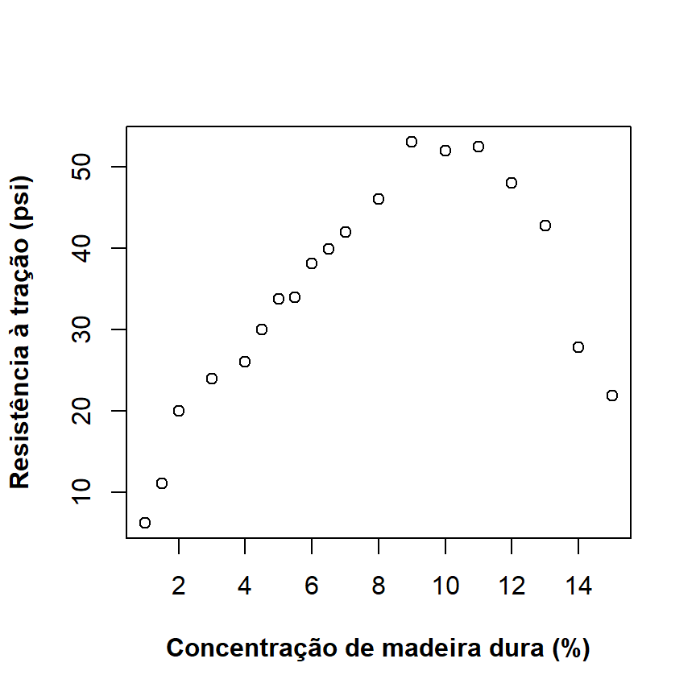

## Padronizando a variável \(X\)

Correlação entre \(X\), \(X^2\), \(X^3\), \(X^4\)

```
##        x    x2    x3    x4
## x  1.000 0.970 0.921 0.874
## x2 0.970 1.000 0.987 0.961
## x3 0.921 0.987 1.000 0.993
## x4 0.874 0.961 0.993 1.000
```

Seja \(X_* = X - \bar{X}\)

Correlação entre \(X_*\), \(X_*^2\), \(X_*^3\), \(X_*^4\)

```
##        x_c  x_c2  x_c3  x_c4
## x_c  1.000 0.297 0.910 0.399
## x_c2 0.297 1.000 0.424 0.948
## x_c3 0.910 0.424 1.000 0.574
## x_c4 0.399 0.948 0.574 1.000
```

## Ajuste regressão linear simples

```
##             Estimate Std. Error  t value Pr(>|t|)
## (Intercept) 34.18421    2.71075 12.61061  0.00000
## x_c          1.77099    0.64781  2.73379  0.01414
```

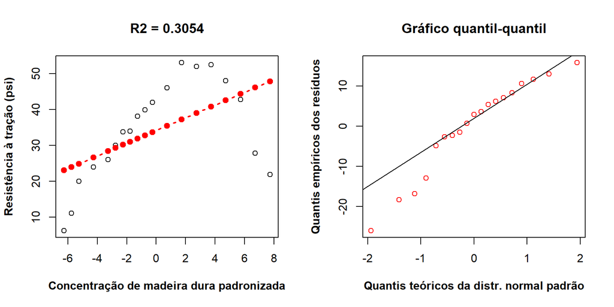

## Ajuste polinômio grau 2

```
##              Estimate Std. Error   t value Pr(>|t|)
## (Intercept) 45.294973   1.482873  30.54542        0
## x_c          2.546344   0.253839  10.03134        0
## x_c2        -0.634549   0.061788 -10.26973        0
```

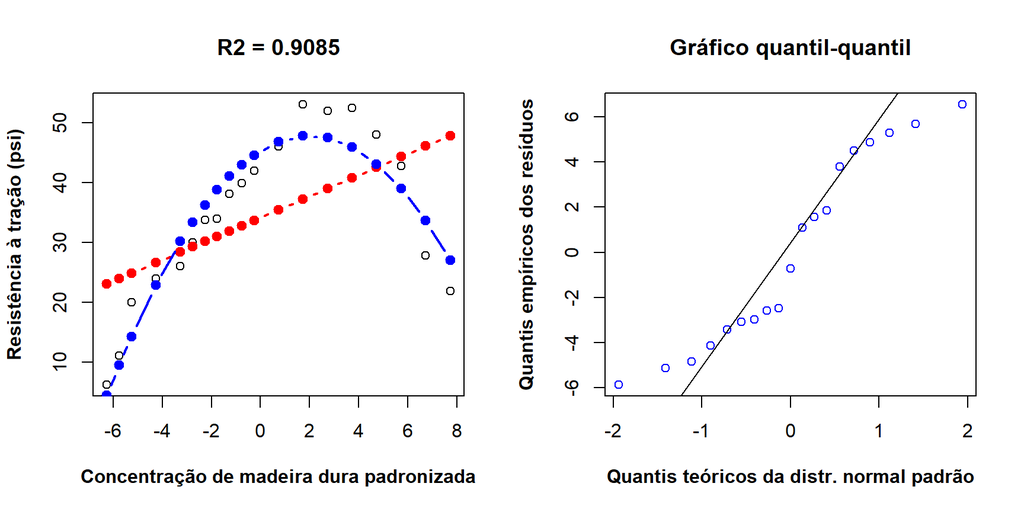

## Ajuste polinômio grau 3

```
##             Estimate Std. Error   t value Pr(>|t|)
## (Intercept) 44.97556    0.86903  51.75362    0e+00
## x_c          4.33939    0.35098  12.36373    0e+00
## x_c2        -0.54887    0.03920 -14.00210    0e+00
## x_c3        -0.05519    0.00979  -5.63781    5e-05
```

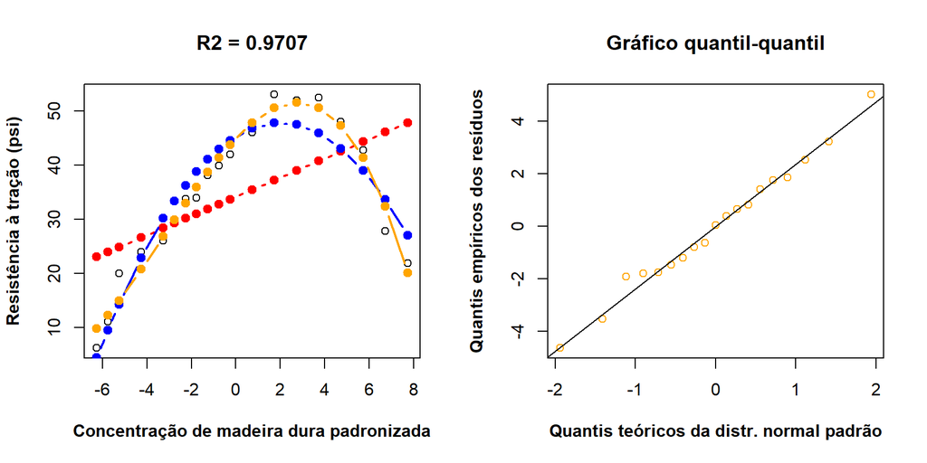

## Ajuste polinômio grau 4

```
##             Estimate Std. Error  t value Pr(>|t|)
## (Intercept) 44.16512    1.07282 41.16746  0.00000
## x_c          4.11527    0.38874 10.58616  0.00000
## x_c2        -0.39417    0.12993 -3.03364  0.00894
## x_c3        -0.04527    0.01248 -3.62759  0.00274
## x_c4        -0.00351    0.00281 -1.24665  0.23298
```

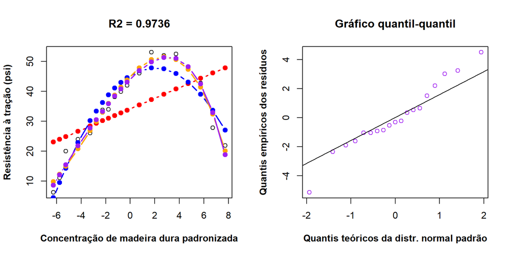

## Soma extra de quadrados e teste F

```r
anova(m4)
```

```
## Analysis of Variance Table
##
## Response: y
##           Df  Sum Sq Mean Sq  F value    Pr(>F)
## x_c        1 1043.43 1043.43 161.9124 4.392e-09 ***
## x_c2       1 2060.82 2060.82 319.7849 4.874e-11 ***
## x_c3       1  212.40  212.40  32.9591 5.104e-05 ***
## x_c4       1   10.02   10.02   1.5541     0.233
## Residuals 14   90.22    6.44
## ---
## Signif. codes:  0 '***' 0.001 '**' 0.01 '*' 0.05 '.' 0.1 ' ' 1
```

```r
round(summary(m3)$coefficient,5)
```

```
##             Estimate Std. Error   t value Pr(>|t|)
## (Intercept) 44.97556    0.86903  51.75362    0e+00
## x_c          4.33939    0.35098  12.36373    0e+00
## x_c2        -0.54887    0.03920 -14.00210    0e+00
## x_c3        -0.05519    0.00979  -5.63781    5e-05
```

## Extrapolação

A extrapolação de modelos polinomiais para valores de \(x\) fora do intervalo observado nos dados pode ser extremamente perigosa.

## Modelo com dois preditores - segunda ordem

Vamos considerar um modelo de segunda ordem com duas variáveis preditoras \(X_1\) e \(X_2\)

\[Y=\beta_0+\beta_1X_{1*}+\beta_2X_{1*}^2+\beta_3X_{2*}+\beta_4X_{2*}^2+\beta_5X_{1*}X_{2*}+\varepsilon\]

em que \(X_{1*}=X_1-\bar{X}_1\) e \(X_{2*}=X_2-\bar{X}_2\).

## Exemplo

\[E(Y)=\beta_0+\beta_1X_{1*}+\beta_2X_{1*}^2+\beta_3X_{2*}+\beta_4X_{2*}^2+\beta_5X_{1*}X_{2*}\]

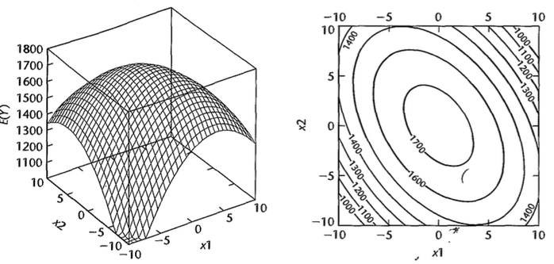

## Método hierárquico de ajuste de modelo

Pode-se começar com um modelo de segunda ou terceira ordem e ir testando se os coeficientes de ordem maiores são significativos.

Por exemplo:

\[Y=\beta_0+\beta_1X_{*}+\beta_2X_*^2+\beta_3X_*^3+\varepsilon\]

Para testar se \(\beta_3=0\) podemos utilizar \(SQReg(X_*^3\mid X_*,X_*^2)\). Se quisermos testar se \(\beta_2=\beta_3=0\):

\[SQReg(X_*^2,X_*^3\mid X_*)=SQReg(X_*^2\mid X_*)+SQReg(X_*^3\mid X_*, X_*^2)\]

**Se um termo de ordem mais alta é mantido no modelo, os de ordem mais baixa devem obrigatoriamente ser mantidos também.**

## Exemplo

Dados de um experimento realizado para estudar o efeito de duas variáveis, temperatura de reação \((T)\) e concentração de reagente \((C)\), na conversão percentual de um processo químico \((Y)\)

```
##            T     C  Y       T_p       C_p
##  [1,] 200.00 15.00 43 -1.172692 -1.172692
##  [2,] 250.00 15.00 78  1.172692 -1.172692
##  [3,] 200.00 25.00 69 -1.172692  1.172692
##  [4,] 250.00 25.00 73  1.172692  1.172692
##  [5,] 189.65 20.00 48 -1.658187  0.000000
##  [6,] 260.35 20.00 76  1.658187  0.000000
##  [7,] 225.00 12.93 65  0.000000 -1.658187
##  [8,] 225.00 27.07 74  0.000000  1.658187
##  [9,] 225.00 20.00 76  0.000000  0.000000
## [10,] 225.00 20.00 79  0.000000  0.000000
## [11,] 225.00 20.00 83  0.000000  0.000000
## [12,] 225.00 20.00 81  0.000000  0.000000
```

## Exemplo

\[Y=\beta_0+\beta_1X_{1*}+\beta_2X_{2*}+\beta_3X_{1*}^2+\beta_4X_{2*}^2+\beta_5X_{1*}X_{2*}+\varepsilon\]

```
##               Estimate Std. Error   t value     Pr(>|t|)
## (Intercept)  79.749999  1.2135308 65.717328 8.349138e-10
## C_p           3.595475  0.7317866  4.913284 2.674827e-03
## T_p           8.378568  0.7317866 11.449469 2.664055e-05
## I(C_p^2)     -3.727066  0.6977733 -5.341372 1.758987e-03
## I(T_p^2)     -6.454751  0.6977733 -9.250499 9.015512e-05
## I(C_p * T_p) -5.635513  0.8824346 -6.386323 6.935235e-04
```

```
## Analysis of Variance Table
##
## Response: Y
##              Df Sum Sq Mean Sq F value    Pr(>F)
## C_p           1 142.20  142.20  24.140 0.0026748 **
## T_p           1 772.20  772.20 131.090 2.664e-05 ***
## I(C_p^2)      1  74.85   74.85  12.706 0.0118622 *
## I(T_p^2)      1 504.07  504.07  85.572 9.016e-05 ***
## I(C_p * T_p)  1 240.25  240.25  40.785 0.0006935 ***
## Residuals     6  35.34    5.89
## ---
## Signif. codes:  0 '***' 0.001 '**' 0.01 '*' 0.05 '.' 0.1 ' ' 1
```

## Será que um modelo de primeira ordem já seria suficiente?

- \(H_0\): \(\beta_q=\beta_{q+1}=\ldots=\beta_{p-1}=0\).
- \(H_1\): pelo menos um \(\beta_q,\ldots,\beta_{p-1}\) não é zero.

(por conveniência, a notação assume que os últimos \(p-q\) coeficientes do modelo serão testados)

Estatística do teste:

\[\begin{eqnarray} F^*&=&\frac{SQReg(X_q,\ldots, X_{p-1}\mid X_1,\ldots,X_{q-1})}{p-q}\div\frac{SQE(X_1,\ldots,X_{p-1})}{n-p}\\ &\overset{\mbox{sob $H_0$}}{\sim}&F_{p-q,n-p} \end{eqnarray}\]

## Exemplo

\(p =6\) ; \(n = 12\) e \(q = 3\)

\[\begin{eqnarray} SQReg(X_{1*}^2,X_{2*}^2,X_{1*}X_{2*}\mid X_{1*},X_{2*}) &=& SQReg(X_{1*}^2\mid X_{1*},X_{2*})\\ &+& SQReg(X_{2*}^2\mid X_{1*},X_{2*},X_{1*}^2)\\ &+&SQReg(X_{1*}X_{2*}\mid X_{1*},X_{2*},X_{1*}^2,X_{2*}^2)\\ &=&74.8 + 504.1 +240.25\\ &=& 819.15 \end{eqnarray}\]

\[F_{obs}=\frac{819.15/3}{5.9}=46.279661\]

## Exemplo

```r
modeloreduz <- lm(Y ~ C_p + T_p)
anova(modeloreduz, modelo)
```

```
## Analysis of Variance Table
##
## Model 1: Y ~ C_p + T_p
## Model 2: Y ~ C_p + T_p + I(C_p^2) + I(T_p^2) + I(C_p * T_p)
##   Res.Df    RSS Df Sum of Sq      F    Pr(>F)
## 1      9 854.51
## 2      6  35.34  3    819.17 46.354 0.0001524 ***
## ---
## Signif. codes:  0 '***' 0.001 '**' 0.01 '*' 0.05 '.' 0.1 ' ' 1
```

## Modelo de Regressão com Interação

## Efeitos de interação

Um modelo de regressão com \(p-1\) variáveis preditoras com efeitos aditivos tem função de regressão da forma:

\[E(Y)=f_1(X_1)+f_2(X_2)+\ldots+f_{p-1}(X_{p-1})\]

em que \(f_1,f_2,\ldots,f_{p-1}\) podem ser quaisquer funções.

Por exemplo:

\[E(Y)=\underbrace{\beta_0+\beta_1X_1+\beta_2X_1^2}_{f_1(X_1)}+\underbrace{\beta_3X_2}_{f_2(X_2)}\]

O efeito de \(X_1\) e \(X_2\) em \(Y\) é **aditivo**.

## Efeitos de interação

Já no exemplo a seguir, o efeito não é aditivo, há efeito de interação:

\[E(Y)=\beta_0+\beta_1X_1+\beta_2X_1^2+\beta_3X_2+\beta_4X_1X_2\]

Outro exemplo:

\[E(Y)=\beta_0+\beta_1X_1+\beta_2X_2+\beta_3X_3+\beta_4X_1X_2+\beta_5X_1X_3\]

**O efeito de uma variável sobre \(Y\) irá depender do nível da variável com a qual ela interage.**

## Interpretação: interação e efeitos lineares

\[Y=\beta_0+\beta_1X_1+\beta_2X_2+\beta_3X_1X_2+\varepsilon\]

Suponha que \(X_1=a\):

\[E(Y)=\beta_0+\beta_1a+\beta_2X_2+\beta_3aX_2\]

Suponha que \(X_1=a+1\):

\[E(Y)=\beta_0+\beta_1(a+1)+\beta_2X_2+\beta_3(a+1)X_2\]

Diferença no valor esperado de \(Y\) quando aumentamos \(X_1\) em 1 unidade:

\[\beta_0+\beta_1(a+1)+\beta_2X_2+\beta_3(a+1)X_2 - (\beta_0+\beta_1a+\beta_2X_2+\beta_3aX_2)\]

\[=\beta_1+\beta_3X_2\]

## Interpretação: interação e efeitos lineares

\[Y=\beta_0+\beta_1X_1+\beta_2X_2+\beta_3X_1X_2+\varepsilon\]

Suponha que \(X_2=a\):

\[E(Y)=\beta_0+\beta_1X_1+\beta_2a+\beta_3X_1a\]

Suponha que \(X_2=a+1\):

\[E(Y)=\beta_0+\beta_1X_1+\beta_2(a+1)+\beta_3X_1(a+1)\]

Diferença no valor esperado de \(Y\) quando aumentamos \(X_2\) em 1 unidade:

\[\beta_0+\beta_1X_1+\beta_2(a+1)+\beta_3X_1(a+1) - (\beta_0+\beta_1X_1+\beta_2a+\beta_3X_1a)\]

\[=\beta_2+\beta_3X_1\]

## Interpretação: interação e efeitos lineares

\[Y=\beta_0+\beta_1X_1+\beta_2X_2+\beta_3X_1X_2+\varepsilon\]

Diferença no valor esperado de \(Y\) quando aumentamos \(X_1\) em 1 unidade:

\[\frac{\partial E(Y)}{\partial X_1}=\beta_1+\beta_3X_2\]

Diferença no valor esperado de \(Y\) quando aumentamos \(X_2\) em 1 unidade:

\[\frac{\partial E(Y)}{\partial X_2}=\beta_2+\beta_3X_1\]

## Interpretação: interação e efeitos lineares

Modelo aditivo:

\[E(Y)=10+2X_1+5X_2\]

\(\beta_1\): mudança no valor esperado de \(Y\) quando \(X_1\) aumenta em 1 unidade, mantendo \(X_2\) constante.

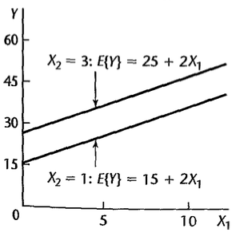

Mantendo \(X_2\) constante: não importa se \(X_2=1\) ou \(X_2=3\) o efeito é sempre \(\beta_1\) no valor esperado quando \(X_1\) aumenta em 1 unidade (retas paralelas).

## Interpretação: interação e efeitos lineares

Modelo com interação:

\[E(Y)=10+2X_1+5X_2 +0.5X_1X_2\]

Se \(X_2=1\):

\[E(Y)=10+2X_1+5\times1 +0.5X_1\times 1=15+2.5X_1\]

Se \(X_2=3\):

\[E(Y)=10+2X_1+5\times3 +0.5X_1\times 3=25+3.5X_1\]

## Interpretação: interação e efeitos lineares

Para avaliarmos o efeito de 1 unidade de aumento em \(X_1\), devemos considerar o valor de \(X_2\) (retas não paralelas).

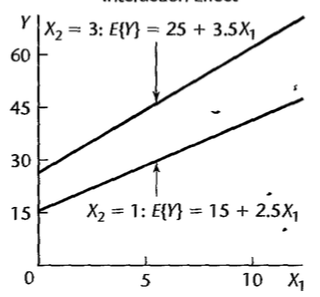

## Interpretação: interação e efeitos curvilinear

Exemplo:

\[E(Y)=65+3X_1+4X_2-10X_1^2-15X_2^2+35X_1X_2\]

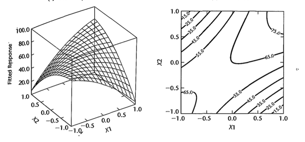

## Interpretação: interação e efeitos curvilinear

Se \(X_1=1\):

\[E(Y)=65+3\times 1+4X_2-10\times(1^2)-15X_2^2+35\times 1\times X_2\]

\[E(Y)=58+39X_2-15X_2^2\]

Se \(X_1=-1\):

\[E(Y)=65+3\times (-1)+4X_2-10\times(-1^2)-15X_2^2+35\times (-1)\times X_2\]

\[E(Y)=52-31X_2-15X_2^2\]

## Interpretação: interação e efeitos curvilinear

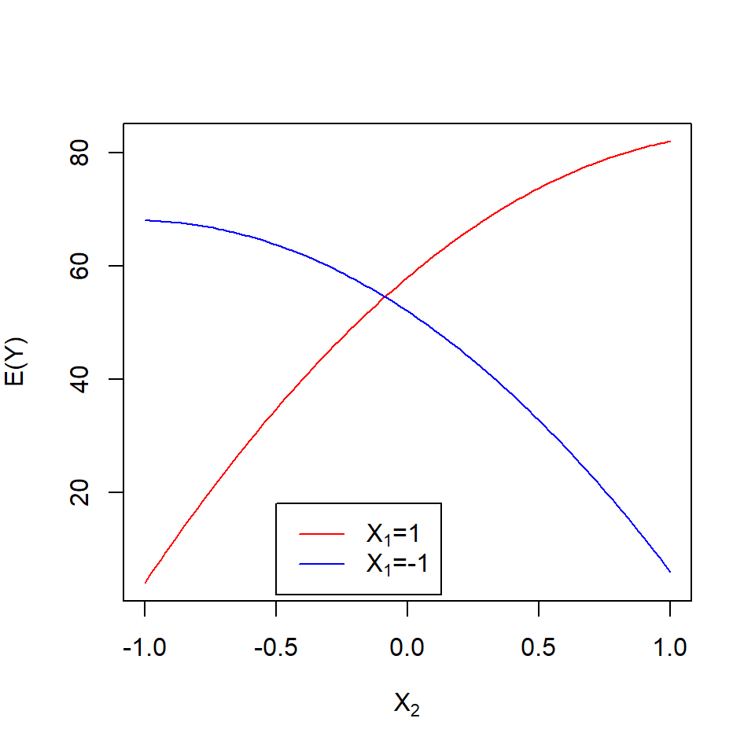

## Exemplo

\(X_1\): tríceps, \(X_{1*}=X_1-\bar{X}_1\).

\(X_2\): coxa, \(X_{2*}=X_2-\bar{X}_2\).

\(X_3\): antebraço, \(X_{3*}=X_1-\bar{X}_3\).

\(Y\): gordura corporal

## Exemplo

| X1 | X2 | X3 | Y | x1 | x2 | x3 |
| --- | --- | --- | --- | --- | --- | --- |
| 19.5 | 43.1 | 29.1 | 11.9 | -5.805 | -8.07 | 1.48 |
| 24.7 | 49.8 | 28.2 | 22.8 | -0.605 | -1.37 | 0.58 |
| 30.7 | 51.9 | 37.0 | 18.7 | 5.395 | 0.73 | 9.38 |
| 29.8 | 54.3 | 31.1 | 20.1 | 4.495 | 3.13 | 3.48 |
| 19.1 | 42.2 | 30.9 | 12.9 | -6.205 | -8.97 | 3.28 |
| 25.6 | 53.9 | 23.7 | 21.7 | 0.295 | 2.73 | -3.92 |
| 31.4 | 58.5 | 27.6 | 27.1 | 6.095 | 7.33 | -0.02 |
| 27.9 | 52.1 | 30.6 | 25.4 | 2.595 | 0.93 | 2.98 |
| 22.1 | 49.9 | 23.2 | 21.3 | -3.205 | -1.27 | -4.42 |
| 25.5 | 53.5 | 24.8 | 19.3 | 0.195 | 2.33 | -2.82 |
| 31.1 | 56.6 | 30.0 | 25.4 | 5.795 | 5.43 | 2.38 |
| 30.4 | 56.7 | 28.3 | 27.2 | 5.095 | 5.53 | 0.68 |
| 18.7 | 46.5 | 23.0 | 11.7 | -6.605 | -4.67 | -4.62 |
| 19.7 | 44.2 | 28.6 | 17.8 | -5.605 | -6.97 | 0.98 |
| 14.6 | 42.7 | 21.3 | 12.8 | -10.705 | -8.47 | -6.32 |
| 29.5 | 54.4 | 30.1 | 23.9 | 4.195 | 3.23 | 2.48 |
| 27.7 | 55.3 | 25.7 | 22.6 | 2.395 | 4.13 | -1.92 |
| 30.2 | 58.6 | 24.6 | 25.4 | 4.895 | 7.43 | -3.02 |
| 22.7 | 48.2 | 27.1 | 14.8 | -2.605 | -2.97 | -0.52 |
| 25.2 | 51.0 | 27.5 | 21.1 | -0.105 | -0.17 | -0.12 |

## Exemplo

\[E(Y)=\beta_0+\beta_1X_{1*}+\beta_2X_{2*}+\beta_3X_{3*}+\beta_4X_{1*}X_{2*}+\beta_5X_{1*}X_{3*}+\beta_6X_{2*}X_{3*}+\varepsilon\]

```r
modelo <- lm(Y ~ x1 + x2 + x3 + I(x1*x2) + I(x1*x3) + I(x2*x3),data=dat)
summary(modelo)$coef
```

```
##                 Estimate Std. Error    t value     Pr(>|t|)
## (Intercept) 20.526893531 1.07362646 19.1192136 6.699796e-11
## x1           3.437808068 3.57866572  0.9606396 3.542612e-01
## x2          -2.094717339 3.03676957 -0.6897848 5.024579e-01
## x3          -1.616337237 1.90721068 -0.8474875 4.120550e-01
## I(x1 * x2)   0.008875562 0.03085046  0.2876963 7.781144e-01
## I(x1 * x3)  -0.084790836 0.07341774 -1.1549093 2.689155e-01
## I(x2 * x3)   0.090415385 0.09200130  0.9827621 3.436619e-01
```

## Exemplo

```r
anova(modelo)
```

```
## Analysis of Variance Table
##
## Response: Y
##            Df Sum Sq Mean Sq F value    Pr(>F)
## x1          1 352.27  352.27 52.2238 6.682e-06 ***
## x2          1  33.17   33.17  4.9173   0.04503 *
## x3          1  11.55   11.55  1.7117   0.21343
## I(x1 * x2)  1   1.50    1.50  0.2217   0.64552
## I(x1 * x3)  1   2.70    2.70  0.4009   0.53760
## I(x2 * x3)  1   6.51    6.51  0.9658   0.34366
## Residuals  13  87.69    6.75
## ---
## Signif. codes:  0 '***' 0.001 '**' 0.01 '*' 0.05 '.' 0.1 ' ' 1
```

## Exemplo

\(H_0\): \(\beta_4=\beta_5=\beta_6=0\)

\(H_1\): pelo menos um dentre \(\beta_4,\beta_5,\beta_6\) é diferente de 0.

\(p=7\)

\(n = 20\)

\(q=4\)

\[F^*=\frac{SQReg(X_{1*}X_{2*},X_{1*}X_{3*},X_{2*}X_{3*}\mid X_{1*},X_{2*},X_{3*})/3}{SQE(X_{1*},X_{2*},X_{3*},X_{1*}X_{2*},X_{1*}X_{3*},X_{2*}X_{3*})/13}\overset{\mbox{sob $H_0$}}{\sim}F_{3,13}\]

## Exemplo

\[\begin{eqnarray} SQReg(X_{1*}X_{2*},X_{1*}X_{3*},X_{2*}X_{3*}\mid X_{1*},X_{2*},X_{3*}) &=& SQReg(X_{1*}X_{2*}\mid X_{1*},X_{2*},X_{3*})\\ &+& SQReg(X_{1*}X_{3*}\mid X_{1*},X_{2*},X_{3*},X_{1*}X_{2*})\\ &+&SQReg(X_{2*}X_{3*}\mid X_{1*},X_{2*},X_{3*},X_{1*}X_{2*},X_{1*}X_{3*})\\ &=&1.5 + 2.7 +6.514836\\ &=& 10.714836 \end{eqnarray}\]

\[F_{obs}=\frac{10.714836/3}{6.7}=0.5330764\]

Comparando com \(F(0.95;3,13)=3.41\), não encontramos evidências contra a hipótese nula.

## Exemplo

```r
modeloreduz <- lm(Y ~ x1 + x2 + x3,data=dat)
anova(modeloreduz,modelo)
```

```
## Analysis of Variance Table
##
## Model 1: Y ~ x1 + x2 + x3
## Model 2: Y ~ x1 + x2 + x3 + I(x1 * x2) + I(x1 * x3) + I(x2 * x3)
##   Res.Df    RSS Df Sum of Sq      F Pr(>F)
## 1     16 98.405
## 2     13 87.690  3    10.715 0.5295 0.6699
```

## Preditores Qualitativos

## Exemplo: Seguros

\(Y\) = meses até a implementação

\(X_1\) = tamanho da firma (em milhões de dólares)

\[\begin{eqnarray} X_2 = \begin{cases} 1, & \mbox{se a firma tem ações na bolsa} \\ 0, & \mbox{caso contrário} \end{cases} \end{eqnarray}\]

\[Y=\beta_0+\beta_1X_1+\beta_2X_2+\varepsilon\]

\[E(Y)=\beta_0+\beta_1X_1+\beta_2X_2\]

## Exemplo: Seguros

\[E(Y)=\beta_0+\beta_1X_1+\beta_2X_2\]

Se a firma não tem ações na bolsa, então \(X_2=0\):

\[E(Y)=\beta_0+\beta_1X_1\]

Se a firma tem ações na bolsa, então \(X_2=1\):

\[E(Y)=(\beta_0+\beta_2)+\beta_1X_1\]

## Exemplo: Seguros

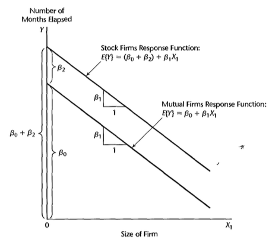

## Exemplo: Seguros

```
##     Y  X1 X2
## 1  17 151  0
## 2  26  92  0
## 3  21 175  0
## 4  30  31  0
## 5  22 104  0
## 6   0 277  0
## 7  12 210  0
## 8  19 120  0
## 9   4 290  0
## 10 16 238  0
## 11 28 164  1
## 12 15 272  1
## 13 11 295  1
## 14 38  68  1
## 15 31  85  1
## 16 21 224  1
## 17 20 166  1
## 18 13 305  1
## 19 30 124  1
## 20 14 246  1
```

## Exemplo: Seguros

```
##               Estimate  Std. Error    t value     Pr(>|t|)
## (Intercept) 33.8740690 1.813858297  18.675146 9.145269e-13
## X1          -0.1017421 0.008891218 -11.442990 2.074687e-09
## X2           8.0554692 1.459105700   5.520826 3.741874e-05
```

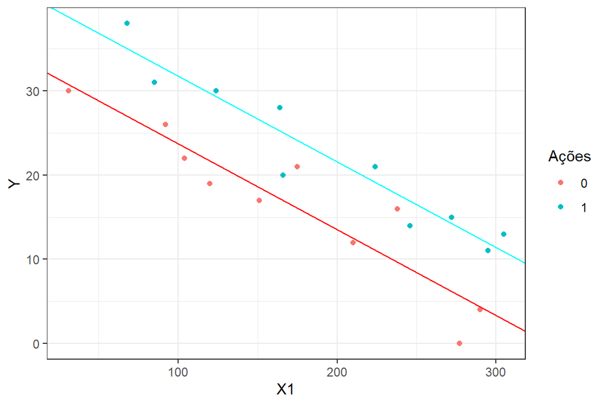

## Exemplo: Seguros

Incluindo termo de interação:

\[Y=\beta_0+\beta_1X_1+\beta_2X_2+\beta_3X_1X_2+\varepsilon\]

\[E(Y)=\beta_0+\beta_1X_1+\beta_2X_2+\beta_3X_1X_2\]

Se a firma não tem ações na bolsa, então \(X_2=0\):

\[E(Y)=\beta_0+\beta_1X_1\]

Se a firma tem ações na bolsa, então \(X_2=1\):

\[E(Y)=(\beta_0+\beta_2)+(\beta_1+\beta_3)X_1\]

## Exemplo: Seguros

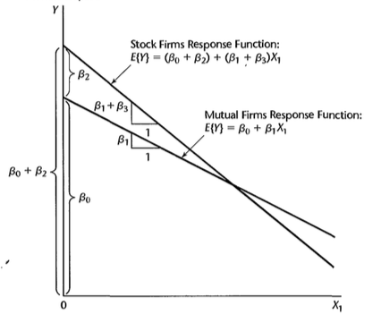

## Exemplo: Seguros

```r
modelo <- lm(Y ~ X1 + X2 + X1*X2, data=dados); round(summary(modelo)$coef,5)
```

```
##             Estimate Std. Error  t value Pr(>|t|)
## (Intercept) 33.83837    2.44065 13.86449  0.00000
## X1          -0.10153    0.01305 -7.77861  0.00000
## X2           8.13125    3.65405  2.22527  0.04079
## X1:X2       -0.00042    0.01833 -0.02276  0.98213
```

```r
modelo <- lm(Y ~ X1*X2, data=dados); round(summary(modelo)$coef,5)
```

```
##             Estimate Std. Error  t value Pr(>|t|)
## (Intercept) 33.83837    2.44065 13.86449  0.00000
## X1          -0.10153    0.01305 -7.77861  0.00000
## X2           8.13125    3.65405  2.22527  0.04079
## X1:X2       -0.00042    0.01833 -0.02276  0.98213
```

## Exemplo: Seguros

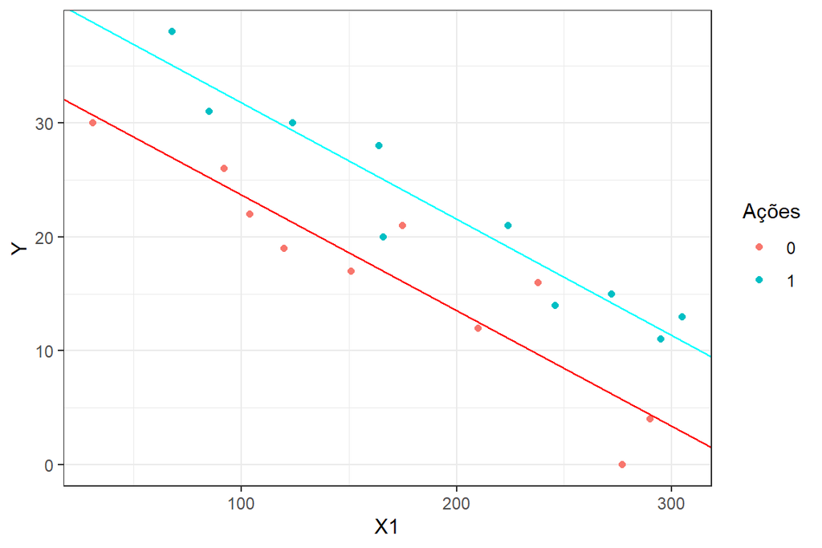

## Variável preditora com **mais de duas classes**

Exemplo: Salário \((Y)\), anos de experiência desde a última titulação \((X_1)\) e uma variável qualitativa \(titulo\) que indica o grau de titulação do funcionário.

Existem 3 níveis de titulação: bacharel, mestre e doutor.

Definimos 2 variáveis *dummy* ou indicadoras:

\[\begin{eqnarray} X_2 = \begin{cases} 1, & \mbox{se mestre} \\ 0, & \mbox{caso contrário} \end{cases} \end{eqnarray}\]

\[\begin{eqnarray} X_3 = \begin{cases} 1, & \mbox{se doutor} \\ 0, & \mbox{caso contrário} \end{cases} \end{eqnarray}\]

Paramétrização por *casela de referência* a escolha de qual o nível será a referência é arbitrária.

## Variável preditora com mais de duas classes

\[E(Y)=\beta_0+\beta_1X_1+\beta_2X_2+\beta_3X_3\]

Se título = bacharel:

\[E(Y)=\beta_0+\beta_1X_1+\beta_2\times0+\beta_3\times0=\beta_0+\beta_1X_1\]

Se o título = mestre:

\[E(Y)=\beta_0+\beta_1X_1+\beta_2\times1+\beta_3\times0=(\beta_0+\beta_2)+\beta_1X_1\]

Se o título = doutor:

\[E(Y)=\beta_0+\beta_1X_1+\beta_2\times0+\beta_3\times1=(\beta_0+\beta_3)+\beta_1X_1\]

O modelo de primeira ordem implica no fato de que o efeito dos anos de experiência é linear e com o mesmo coeficiente angular para todos os níveis de titularidade. Temos diferentes interceptos para cada modelo.

## Variável preditora com mais de duas classes

- \(\beta_1\): mudança esperada no salário médio \((Y)\) para cada unidade de aumento nos anos de experiência \((X_1)\), considerando o mesmo nível de titularidade.
- \(\beta_2\): diferença esperada no salário médio do bacharel para o mestre, considerando a mesma velocidade.
- \(\beta_3\): diferença esperada no salário médio do bacharel para o doutor, considerando a mesma velocidade.

## Variável preditora com mais de duas classes

```
##        Y    X1   titulo
## 1   58.8  4.49   doutor
## 2   34.8  2.92 bacharel
## 3  163.7 29.54   doutor
## 4   70.0  9.92   doutor
## 5   55.5  0.14   doutor
## 6   85.0 15.96   mestre
## 7   34.0  2.27 bacharel
## 8   29.7  1.20 bacharel
## 9   56.1  5.33   mestre
## 10  70.6 15.74   doutor
```

## Variável preditora com mais de duas classes

```
##              Estimate Std. Error  t value     Pr(>|t|)
## (Intercept)  25.79587  4.0030933 6.443984 2.072072e-08
## X1            2.38670  0.2590196 9.214361 3.704340e-13
## titulomestre 13.38309  4.6068743 2.905025 5.109154e-03
## titulodoutor 28.56642  4.9012373 5.828410 2.265887e-07
```

```
## Analysis of Variance Table
##
## Response: Y
##           Df  Sum Sq Mean Sq F value    Pr(>F)
## X1         1 24851.9 24851.9 116.708 8.546e-16 ***
## titulo     2  7342.7  3671.4  17.241 1.161e-06 ***
## Residuals 61 12989.4   212.9
## ---
## Signif. codes:  0 '***' 0.001 '**' 0.01 '*' 0.05 '.' 0.1 ' ' 1
```

## Variável preditora com mais de duas classes

Qual a diferença esperada no salário médio entre o mestre o doutor?

Quando o título é mestre temos que:

\[E(Y)=(\beta_0+\beta_2)+\beta_1X_1\]

Quando o título é doutor temos que:

\[E(Y)=(\beta_0+\beta_3)+\beta_1X_1\]

A diferença entre mestre e doutor, mantendo os anos de experiência:

\[(\beta_0+\beta_3)+\beta_1X_1 - [(\beta_0+\beta_2)+\beta_1X_1] = \beta_3-\beta_2\]

## Variável preditora com mais de duas classes

Após obtermos estimativas: \(\hat{\beta}_3-\hat{\beta}_2\) e devemos também fornecer o erro-padrão da estimativa.

Lembre que:

\[Var(\hat{\beta}_3-\hat{\beta}_2)=Var(\hat{\beta}_3)+Var(\hat{\beta}_2)-2Cov(\hat{\beta}_3,\hat{\beta}_2)\]

## Variável preditora com mais de duas classes

\(\hat{\beta}_3\) - \(\hat{\beta}_2\) = 28.57 - 13.38 = 15.18

\(\hat{Var{(\hat{\beta})}}\)

```
##              (Intercept)    X1 titulomestre titulodoutor
## (Intercept)        16.02 -0.43       -13.03       -11.63
## X1                 -0.43  0.07        -0.04        -0.26
## titulomestre      -13.03 -0.04        21.22        13.48
## titulodoutor      -11.63 -0.26        13.48        24.02
```

\[Var(\hat{\beta}_3-\hat{\beta}_2) = 24.02 + 21.22 - 2 \times 13.48 = 18.28\]

## Exemplo: Fábrica de sabão

\(Y\): resíduo de sabão

\(X_1\): velocidade

\[\begin{eqnarray} X_2 = \begin{cases} 1, & \mbox{se produção na linha 1} \\ 0, & \mbox{caso contrário} \end{cases} \end{eqnarray}\]

## Exemplo: Fábrica de sabão

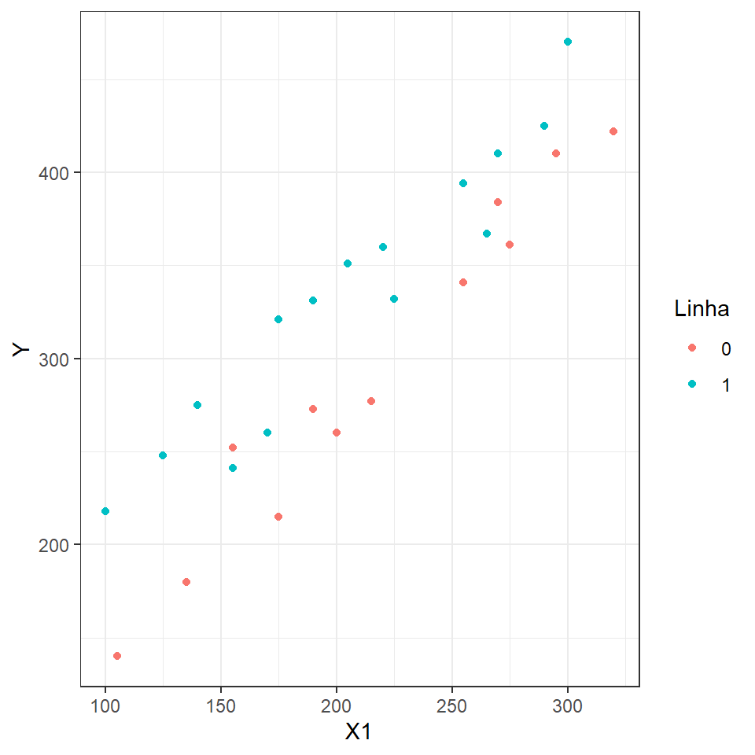

## Exemplo: Fábrica de sabão

Iremos ajustar um modelo assumindo que:

- a relação entre a quantidade de resíduo e velocidade é linear para as duas linhas de produção;
- retas diferentes para as duas linhas de produção;
- as variâncias dos termos de erros ao redor de cada reta são iguais.

\[Y=\beta_0+\beta_1X_1+\beta_2X_2+\beta_3X_1X_2+\varepsilon\]

Para a linha 1: \(E(Y)=(\beta_0+\beta_2)+(\beta_1+\beta_3)X_1\).

Para a linha 2: \(E(Y)=\beta_0+\beta_1X_1\).

## Exemplo: Fábrica de sabão

```r
modelo <- lm(Y ~ X1 + X2 + I(X1*X2), data=dados)
summary(modelo)$coef
```

```
##               Estimate Std. Error    t value     Pr(>|t|)
## (Intercept)  7.5744646 20.8696979  0.3629408 7.199633e-01
## X1           1.3220488  0.0926247 14.2731771 6.446165e-13
## X2          90.3908632 28.3457320  3.1888703 4.085851e-03
## I(X1 * X2)  -0.1766614  0.1288377 -1.3711932 1.835463e-01
```

```r
anova(modelo)
```

```
## Analysis of Variance Table
##
## Response: Y
##            Df Sum Sq Mean Sq  F value    Pr(>F)
## X1          1 149661  149661 347.5548 2.224e-15 ***
## X2          1  18694   18694  43.4129 1.009e-06 ***
## I(X1 * X2)  1    810     810   1.8802    0.1835
## Residuals  23   9904     431
## ---
## Signif. codes:  0 '***' 0.001 '**' 0.01 '*' 0.05 '.' 0.1 ' ' 1
```

## Exemplo: Fábrica de sabão

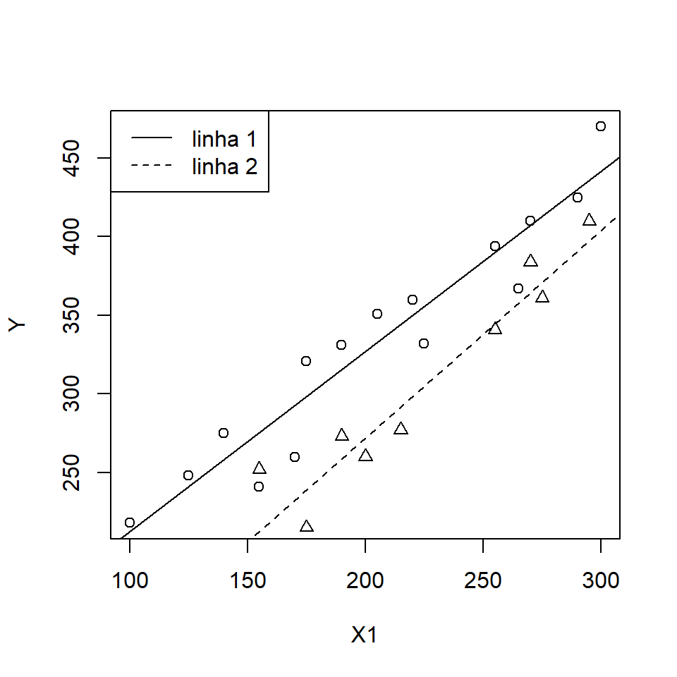

## Exemplo: Fábrica de sabão

Se quisermos testar a hipótese nula de que temos apenas uma reta para representar as duas linhas:

\(H_0\): \(\beta_2=\beta_3=0\)

\(H_a\): pelo menos um entre \(\beta_2\) e \(\beta_3\) é diferente de zero.

Estatística do teste:

\[\begin{eqnarray} F^*&=&\frac{SQReg(X_q,\ldots, X_{p-1}\mid X_1,\ldots,X_{q-1})}{p-q}\div\frac{SQE(X_1,\ldots,X_{p-1})}{n-p}\\ &\overset{\mbox{sob $H_0$}}{\sim}&F_{p-q,n-p} \end{eqnarray}\]

## Exemplo: Fábrica de sabão

\(p=4\)

\(n = 27\)

\(q=2\)

\[F^*=\frac{SQReg(X_2,X_1X_2\mid X_1)/2}{SQE(X_1,X_2,X_1X_2)/23}\overset{\mbox{sob $H_0$}}{\sim}F_{2,23}\]

\[\begin{eqnarray} SQReg(X_2,X_1X_2\mid X_1) &=& SQReg(X_2\mid X_1) + SQReg(X_1X_2\mid X_1,X_2\\ &=&1.86941\times 10^{4} + 809.6\\ &=& 1.95037\times 10^{4} \end{eqnarray}\]

\[F_{obs}=\frac{1.95037\times 10^{4}/2}{430.6}=22.6471203\]

Comparando com \(F(0.95;2,23)=3.42\), encontramos evidências contra a hipótese nula.

## Exemplo: Fábrica de sabão

```r
modeloreduz <- lm(Y ~ X1, data=dados)
anova(modeloreduz,modelo)
```

```
## Analysis of Variance Table
##
## Model 1: Y ~ X1
## Model 2: Y ~ X1 + X2 + I(X1 * X2)
##   Res.Df     RSS Df Sum of Sq      F    Pr(>F)
## 1     25 29407.8
## 2     23  9904.1  2     19504 22.646 3.669e-06 ***
## ---
## Signif. codes:  0 '***' 0.001 '**' 0.01 '*' 0.05 '.' 0.1 ' ' 1
```

## Exemplo: Fábrica de sabão

Se quisermos testar a hipótese nula de que para as duas linhas de produção o coeficiente angular é o mesmo:

\(H_0\): \(\beta_3=0\)

\(H_a\): \(\beta_3\neq0\).

\(p=4\)

\(n = 27\)

\(q=3\)

\[F^*=\frac{SQReg(X_1X_2\mid X_1, X_2)/1}{SQE(X_1,X_2,X_1X_2)/23}\overset{\mbox{sob $H_0$}}{\sim}F_{1,23}\]

## Exemplo: Fábrica de sabão

\[F_{obs}=\frac{809.6/1}{430.6}=1.8801672\]

Comparando com \(F(0.95;1,23)=4.28\), não encontramos evidências contra a hipótese nula.

## Agradecimento

- Slides criados por Samara F Kiihl / IMECC / UNICAMP
- Editado por Rafael P Maia / IMECC / UNICAMP

## Leitura

- Applied Linear Statistical Models: Seções 8.1-8.3, 8.5-8.7.
- Faraway - [Linear Models with R](http://www.maths.bath.ac.uk/~jjf23/LMR/): Capítulo 14.
- Draper & Smith - [Applied Regression Analysis](http://onlinelibrary.wiley.com/book/10.1002/9781118625590): Capítulo 12.